# Runner Data Analysis

#### By: Aaron Stearns

This analysis is on athletic wearable device data. It is a timeseries dataset collected by a single runner over the course of a single workout.

There are many formatting issues and outliers in the data that need to be fixed or normalized before any meaningful analysis can take place, and I’ll walk through those steps over the course of the project.

```r
# Suite of tidy tools
library(tidyverse)
# Date formatting library
library(lubridate)
# Metric-Imperial conversion
library(udunits2)
# ML library with CART algorithm
library(rpart)
```

### Initial Exploration

First, I’ll import the dataset and take a look at the structure, checking the data type of each column:

```r
data <- read.csv("~/runnerData/DS-Interview-Data-2019.csv",
                 stringsAsFactors = F)

str(data)
```

```
## 'data.frame':    34 obs. of  8 variables:
##  $ Laps                  : int  1 2 3 4 5 6 7 8 9 10 ...
##  $ Step.Type             : chr  "warm up" "warm up" "run" "recover" ...
##  $ Time                  : chr  "09:08.8" "04:51.2" "01:30.0" "03:00.0" ...
##  $ Cumulative.Time.Moving: chr  "9:08.8" "14:00" "15:30" "18:30" ...
##  $ Moving.Time           : chr  "9:07" "4:50" "1:29" "2:59" ...
##  $ Distance              : num  1 0.53 0.22 0.34 0.2 0.29 0.17 0.24 0.11 0.18 ...
##  $ Elevation.Gain        : num  NA 45 16 NA NA 17 11 NA NA 20 ...
##  $ Elevation.Loss        : num  115 20 NA 6 29 NA 12 14 NA 14 ...
```

```r
head(data)
```

```
##   Laps Step.Type         Time Cumulative.Time.Moving Moving.Time Distance
## 1    1   warm up      09:08.8                 9:08.8        9:07     1.00
## 2    2   warm up      04:51.2                  14:00        4:50     0.53
## 3    3       run      01:30.0                  15:30        1:29     0.22
## 4    4   recover      03:00.0                  18:30        2:59     0.34
## 5    5       run 12:01:15 AM'                  19.45        1:14     0.20
## 6    6   recover      02:30.0                  22.15        2:27     0.29
##   Elevation.Gain Elevation.Loss
## 1             NA            115
## 2             45             20
## 3             16             NA
## 4             NA              6
## 5             NA             29
## 6             17             NA
```

Very important as well is the summary of each column, which will give clues as to outliers and formatting problems:

```r
summary(data)
```

```
##       Laps        Step.Type             Time
##  Min.   : 1.00   Length:34          Length:34
##  1st Qu.: 9.25   Class :character   Class :character
##  Median :17.50   Mode  :character   Mode  :character
##  Mean   :17.50
##  3rd Qu.:25.75
##  Max.   :34.00
##
##  Cumulative.Time.Moving Moving.Time           Distance
##  Length:34              Length:34          Min.   : 0.0600
##  Class :character       Class :character   1st Qu.: 0.1450
##  Mode  :character       Mode  :character   Median : 0.2000
##                                            Mean   : 0.6015
##                                            3rd Qu.: 0.3150
##                                            Max.   :12.0000
##
##  Elevation.Gain Elevation.Loss
##  Min.   :  10   Min.   :  6.00
##  1st Qu.:  14   1st Qu.: 11.00
##  Median :  20   Median : 15.00
##  Mean   : 141   Mean   : 24.76
##  3rd Qu.:  38   3rd Qu.: 20.00
##  Max.   :2000   Max.   :115.00
##  NA's   :17     NA's   :17
```

Viewing the various data summaries is important, but observing the data in the RStudio IDE is also invaluable:

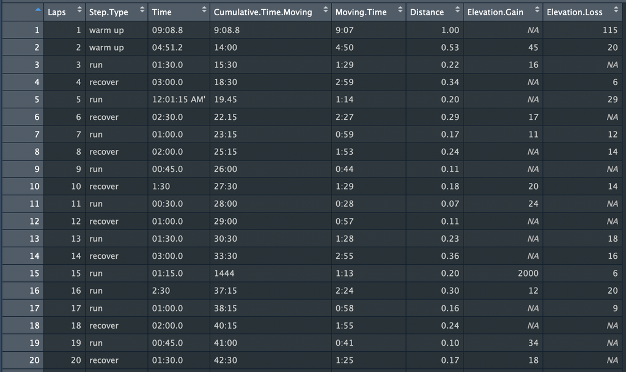

As could be seen from both the summary of the data as well as the image of the dataframe above, it looks like only the `Elevation.Gain` and `Elevation.Loss` columns contain NA values. I’ll go ahead and convert those to zeros:

```r
# Convert NAs to 0s
data[is.na(data)] <- 0

data %>%
  select(Laps, Elevation.Gain, Elevation.Loss) %>%
  head()
```

```
##   Laps Elevation.Gain Elevation.Loss
## 1    1              0            115
## 2    2             45             20
## 3    3             16              0
## 4    4              0              6
## 5    5              0             29
## 6    6             17              0
```

### Functions

In this code block are the functions I wrote to create cumulative time/distance/elevation columns and convert strings to numeric values. The functions are designed to be used more than once on different columns of the data frame, thus following the software best practices of simplicity and DRY.

```r
### Functions ##########################################################

# Splits minute/second strings in formats 01:32, 1:32, 1:32.4 and 01:32.4
# Returns total seconds as numeric (double) eg. "1:32.4" -> 92.4
convertToSeconds <- function(regexCleanedTime) {
  splitTime <- unlist(str_split(regexCleanedTime, ":"))
  minutesToSeconds <- as.numeric(splitTime[1]) * 60
  seconds <- minutesToSeconds + as.numeric(splitTime[2])
  return(seconds)
}

# Function outputs a list of the incremented cumulative
# value of any numerical column from the data frame. Used
# to create new cumulative value columns for time and distance
createIncrementingCumulative <- function(dataFrame, dataFrameColumn) {
  cumulativeList <- list()
  newVal <- 0

  for (i in 1:nrow(dataFrame)) {
    # Set starting index to first row value
    if (i == 1) {
      newVal <- dataFrame[i, dataFrameColumn]
      cumulativeList <- append(cumulativeList, newVal)
    }
    # Set each subsequent value to increment on previous
    else {
      newVal <- newVal + dataFrame[i, dataFrameColumn]
      cumulativeList <- append(cumulativeList, newVal)
    }
  }
  return(cumulativeList)
}
```

### Time

This block of code formats the `Time` column in the data into a usable form, using several different regular expressions to parse and combine the digits in each observation. We can see in the output the newly created column, `TimeInSeconds` and its parsed values:

```r
timeVector <- as.vector(unlist(data$Time))

# Loop uses regex to extract the minutes and seconds from each Time
# column observation and creates new column in the process
for (i in 1:length(timeVector)) {

  # This takes care of the row with erroneous value: 12:01:15 AM'
  if (str_count(timeVector[i], ":") > 1) {
    time <- str_extract(timeVector[i], "(?<=\\w{2}\\:)\\w{1,2}\\:\\w{1,2}\\.?\\w?")
    data$TimeInSeconds[i] <- convertToSeconds(time)
  }
  # All other minute:second strings with and without partial seconds
  else {
    time <- str_extract(timeVector[i], "\\w{1,2}\\:\\w{1,2}\\.?\\w?")
    data$TimeInSeconds[i] <- convertToSeconds(time)
  }
}

data %>%
  select(Laps, Time, Cumulative.Time.Moving, TimeInSeconds) %>%
  head()
```

```
##   Laps         Time Cumulative.Time.Moving TimeInSeconds
## 1    1      09:08.8                 9:08.8         548.8
## 2    2      04:51.2                  14:00         291.2
## 3    3      01:30.0                  15:30          90.0
## 4    4      03:00.0                  18:30         180.0
## 5    5 12:01:15 AM'                  19.45          75.0
## 6    6      02:30.0                  22.15         150.0
```

The following loop replaces any improper punctuation in the `Moving.Time` column. One observation was `0"29` instead of `0:29`.

```r
for (i in 1:nrow(data)) {
  cleanTimes <- str_replace(data$Moving.Time[i], "[:punct:]{1}", ":")
  data$CleanMovingTime[i] <- convertToSeconds(cleanTimes)
}

data %>%
  select(Laps, Moving.Time, CleanMovingTime) %>%
  head()
```

```
##   Laps Moving.Time CleanMovingTime
## 1    1        9:07             547
## 2    2        4:50             290
## 3    3        1:29              89
## 4    4        2:59             179
## 5    5        1:14              74
## 6    6        2:27             147
```

Now I’ll create a new colummn based off of the `Cumulative.Time.Moving` column with cumulative time in seconds.

```r
data$CumulativeTimeInSeconds <- unlist(createIncrementingCumulative(data, 'TimeInSeconds'))

data %>%
  select(Laps, Cumulative.Time.Moving, CumulativeTimeInSeconds) %>%
  head()
```

```
##   Laps Cumulative.Time.Moving CumulativeTimeInSeconds
## 1    1                 9:08.8                   548.8
## 2    2                  14:00                   840.0
## 3    3                  15:30                   930.0
## 4    4                  18:30                  1110.0
## 5    5                  19.45                  1185.0
## 6    6                  22.15                  1335.0
```

### Distance

To address the potential outlier observed in the `Distance` column earlier, we’ll first take the five number summary of the values in the column:

```r
# Explore Distance column:
fivenum(data$Distance)
```

```
## [1]  0.06  0.14  0.20  0.32 12.00
```

We can clearly see that there is an extreme outlier. Let’s visualize these values in a histogram with the number of bins set to the number of rows in the dataframe:

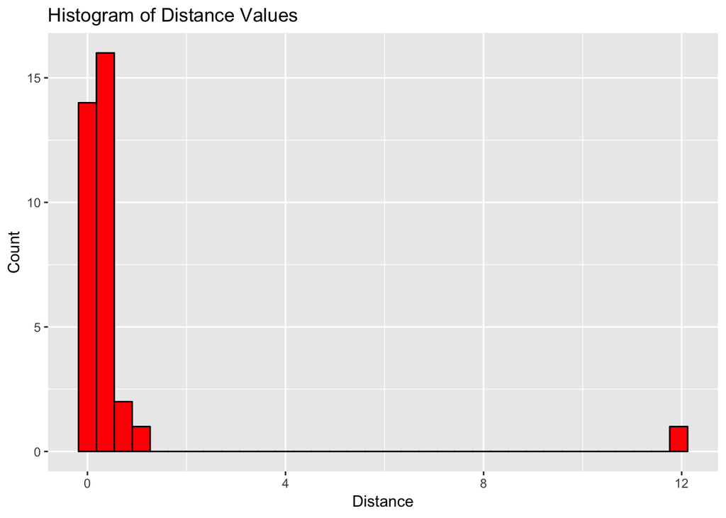

```r
# Visualize the outlier
ggplot(data, aes(x = Distance)) +
  geom_histogram(bins = nrow(data),
                 fill = 'red',
                 color = 'black') +
  theme_gray() +
  xlab("Distance") +
  ylab("Count") +
  ggtitle("Histogram of Distance Values")
```

Now I’ll filter all `Distance` values less than 10 and see the histogram again:

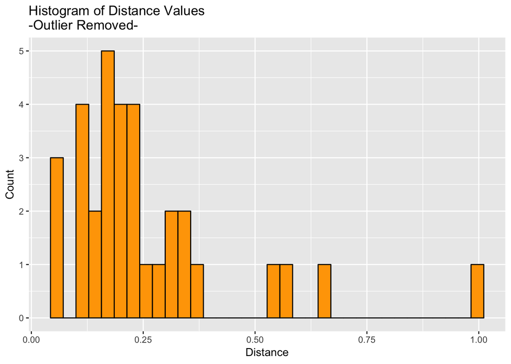

```r
data %>%
  filter(Distance < 10) %>%
  ggplot(aes(x = Distance)) +
  geom_histogram(bins = nrow(data),
                 fill = 'orange',
                 color = 'black') +
  theme_gray() +
  xlab("Distance") +
  ylab("Count") +
  ggtitle("Histogram of Distance Values \n-Outlier Removed-")
```

We can see those same values in a scatter plot, with `Distance` on the X axis and `CleanMovingTime` on the Y axis:

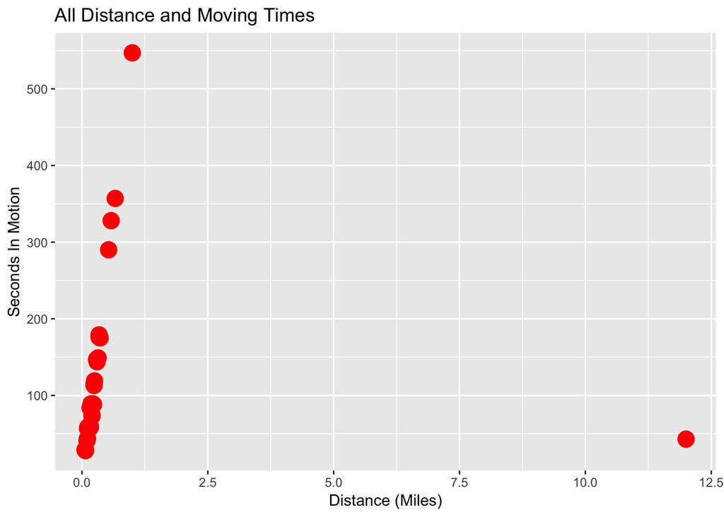

```r
ggplot(data, aes(x = Distance, y = CleanMovingTime)) +
  geom_point(size = 5, color = 'red') +
  theme_gray() +
  xlab("Distance (Miles)") +
  ylab("Seconds In Motion") +
  ggtitle("All Distance and Moving Times")
```

Once again, I’ll filter all `Distance` values less than 10:

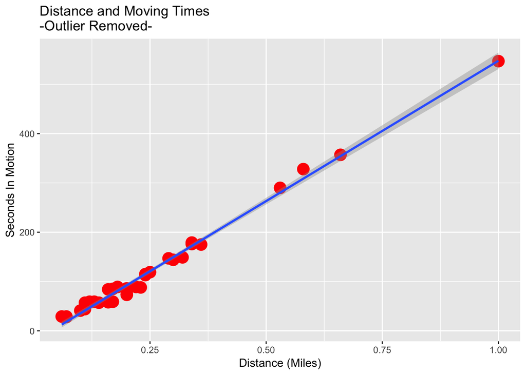

```r
data %>%
  filter(Distance < 10) %>%
  ggplot(aes(x = Distance, y = CleanMovingTime)) +
  geom_point(size = 5, color = 'red') +
  theme_gray() +
  xlab("Distance (Miles)") +
  ylab("Seconds In Motion") +
  ggtitle("Distance and Moving Times \n-Outlier Removed-") +
  geom_smooth(method='lm')
```

Observe potential outliers in ‘Distance’ column:

```r
data %>%
  filter(Distance > .5) %>%
  select(Distance, CleanMovingTime) %>%
  head()
```

```
##   Distance CleanMovingTime
## 1     1.00             547
## 2     0.53             290
## 3    12.00              43
## 4     0.66             357
## 5     0.58             328
```

Here we can observe similar values to the outlier value based on the `CleanMovingTime` column.

```r
data %>%
  filter(CleanMovingTime > 40 & CleanMovingTime < 50) %>%
  select(CleanMovingTime, Distance) %>%
  head()
```

```
##   CleanMovingTime Distance
## 1              44     0.11
## 2              41     0.10
## 3              43    12.00
```

```r
# Bad imputation value, mean pulled up by outlier
```

```
#> mean(data$Distance)
```

```r
#[1] 0.6014706

# Better estimation:
```

```
#> median(data$Distance)
```

```r
#[1] 0.2

# Best imputation:
medianValue <- data %>%
  filter(CleanMovingTime > 40 & CleanMovingTime < 50) %>%
  filter(Distance < 10) %>%
  select(Distance) %>%
  summarise(median(Distance))

print(medianValue)
```

```
##   median(Distance)
## 1            0.105
```

```r
data[data$Distance == 12, 'Distance'] <- medianValue

fivenum(data$Distance)
```

```
## [1] 0.06 0.13 0.20 0.30 1.00
```

```r
data$CumulativeDistance <- unlist(createIncrementingCumulative(data, 'Distance'))

data %>%
  select(Laps, Distance, CumulativeDistance) %>%
  head()
```

```
##   Laps Distance CumulativeDistance
## 1    1     1.00               1.00
## 2    2     0.53               1.53
## 3    3     0.22               1.75
## 4    4     0.34               2.09
## 5    5     0.20               2.29
## 6    6     0.29               2.58
```

Now I’ll take look at the total miles run in the workout:

```r
# Total miles run by runner, outlier excluded
data %>%
  filter(Distance < 10) %>%
  select(Distance) %>%
  sum()
```

```
## [1] 8.555
```

### Meters Per Second:

Now, to better understand the patterns in the runner data, I’ll create a `MetersPerSecond` column.

```r
for (i in 1:nrow(data)) {
  data$MetersPerSecond[i] <- (ud.convert(data$Distance[i], "mi", "km") * 1000) /    data$CleanMovingTime[i]
}

data %>%
  select(Laps, Step.Type, MetersPerSecond) %>%
  head()
```

```
##   Laps Step.Type MetersPerSecond
## 1    1   warm up        2.942128
## 2    2   warm up        2.941215
## 3    3       run        3.978154
## 4    4   recover        3.056855
## 5    5       run        4.349578
## 6    6   recover        3.174896
```

The one missing value in the `Step.Type` column needs to be imputed. I’m going to guess that this missing value is `cool down` based off of the fact that it is at the very end of the workout, it is preceded by a cool down value, and the meters per second between this observation and the previous observation are very similar.

```r
# Include label for final row of Step.Type column
data[data$Laps == nrow(data), 'Step.Type'] <- "cool down"
table(data$Step.Type)
```

```
##
## cool down   recover       run   warm up
##         2        14        16         2
```

### Elevation

Now I’ll work with the potential outlier in the `Elevation.Gain` column.

```r
fivenum(data$Elevation.Gain)
```

```
## [1]    0    0    5   20 2000
```

The mean is very high in comparison to the median, which is a red flag.

```r
mean(data$Elevation.Gain)
```

```
## [1] 70.5
```

```r
median(data$Elevation.Loss)
```

```
## [1] 3
```

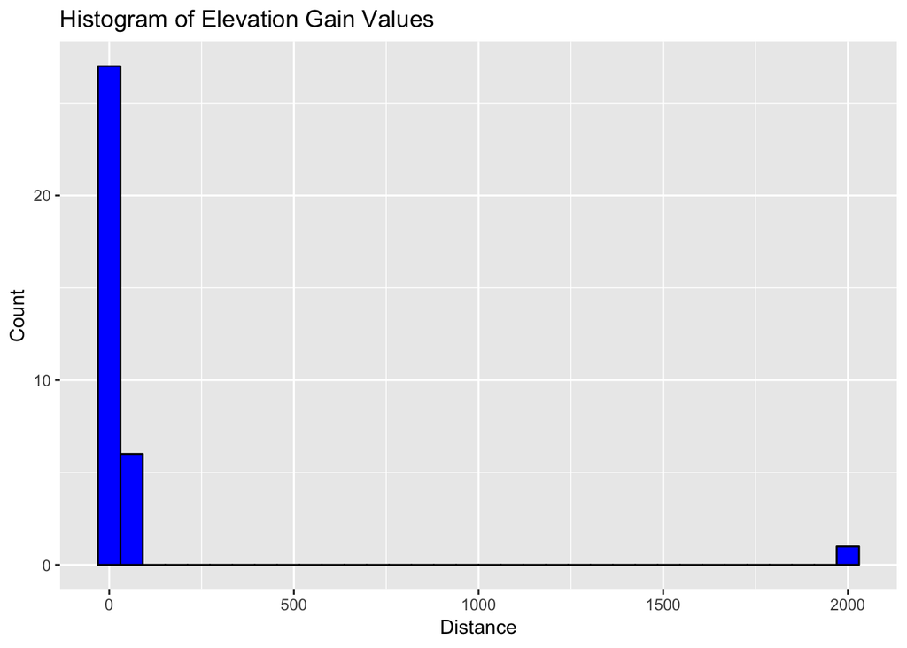

```r
# Visualize the outlier
ggplot(data, aes(x = Elevation.Gain)) +
  geom_histogram(bins = nrow(data),
                 fill = 'blue',
                 color = 'black') +
  theme_gray() +
  xlab("Distance") +
  ylab("Count") +
  ggtitle("Histogram of Elevation Gain Values")
```

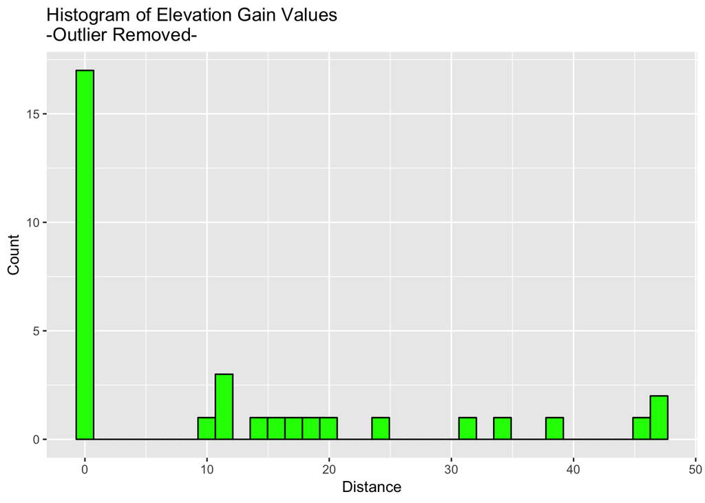

```r
data %>%
  filter(Elevation.Gain < 1000) %>%
  ggplot(aes(x = Elevation.Gain)) +
  geom_histogram(bins = nrow(data),
                 fill = 'green',
                 color = 'black') +
  theme_gray() +
  xlab("Distance") +
  ylab("Count") +
  ggtitle("Histogram of Elevation Gain Values \n-Outlier Removed-")
```

```r
data %>% filter(Elevation.Gain == 2000)
```

```
##   Laps Step.Type    Time Cumulative.Time.Moving Moving.Time Distance
## 1   15       run 01:15.0                   1444        1:13      0.2
##   Elevation.Gain Elevation.Loss TimeInSeconds CleanMovingTime
## 1           2000              6            75              73
##   CumulativeTimeInSeconds CumulativeDistance MetersPerSecond
## 1                    2085               4.25        4.409162
```

```r
data %>% filter(TimeInSeconds > 65 & TimeInSeconds < 85)
```

```
##   Laps Step.Type         Time Cumulative.Time.Moving Moving.Time Distance
## 1    5       run 12:01:15 AM'                  19.45        1:14      0.2
## 2   15       run      01:15.0                   1444        1:13      0.2
## 3   25       run      01:15.0                  49:45        1:14      0.2
##   Elevation.Gain Elevation.Loss TimeInSeconds CleanMovingTime
## 1              0             29            75              74
## 2           2000              6            75              73
## 3             14             15            75              74
##   CumulativeTimeInSeconds CumulativeDistance MetersPerSecond
## 1                    1185               2.29        4.349578
## 2                    2085               4.25        4.409162
## 3                    2985               6.15        4.349578
```

```r
data %>% filter(Elevation.Gain < 1000) %>% summarise(mean(Elevation.Gain))
```

```
##   mean(Elevation.Gain)
## 1              12.0303
```

```r
data[data$Elevation.Gain == 2000, 'Elevation.Gain'] <- median(data$Elevation.Gain)

fivenum(data$Elevation.Gain)
```

```
## [1]  0.0  0.0  2.5 18.0 47.0
```

Now I’ll create a `NetElevationGain` column to visualize elevation gain/loss over the course of the workout.

```r
#### ELEVATION GAIN/LOSS
data <- data %>% mutate(NetElevationGain = Elevation.Gain - Elevation.Loss)

ElevationSeries <- data %>% select(Laps, NetElevationGain)
ElevationSeries <- rbind(c("0", 0), ElevationSeries)

str(ElevationSeries)
```

```
## 'data.frame':    35 obs. of  2 variables:
##  $ Laps            : chr  "0" "1" "2" "3" ...
##  $ NetElevationGain: chr  "0" "-115" "25" "16" ...
```

```r
ElevationSeries <- as.data.frame(sapply(ElevationSeries, as.numeric))

ElevationSeries$NetElevationGain <- unlist(createIncrementingCumulative(ElevationSeries, 'NetElevationGain'))

str(ElevationSeries)
```

```
## 'data.frame':    35 obs. of  2 variables:
##  $ Laps            : num  0 1 2 3 4 5 6 7 8 9 ...
##  $ NetElevationGain: num  0 -115 -90 -74 -80 -109 -92 -93 -107 -107 ...
```

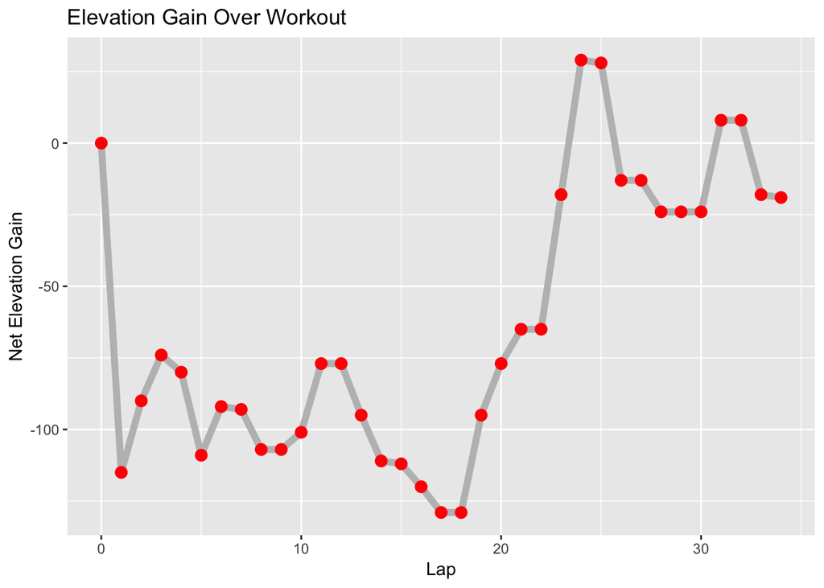

```r
ggplot(ElevationSeries, aes(x = Laps, y = NetElevationGain)) +
  geom_line(size = 2, color = 'grey') +
  geom_point(size = 3, color = 'red') +
  theme_gray()  +
  xlab("Lap") +
  ylab("Net Elevation Gain") +
  ggtitle("Elevation Gain Over Workout")
```

### `Machine Learning Bonus!`

Just for fun, let’s use the newly-created feature `MetersPerSecond` as a variable to predict the `Step.Type` of a given observation.

This will be a multi-class classification problem, with the dependent variable being `Step.Type`.

I’ll use a simple CART (Classification And Regression Tree) with a training set of 80% of the observations to test on the remaining 20%

```r
set.seed(1234)
train_index <- sample(nrow(data), nrow(data) * .8, replace = FALSE)
train <- data[train_index,]
test <- data[-train_index,]

# grow tree
treeFit <- rpart(Step.Type ~ MetersPerSecond,
             method="class", data=train)

# predict 'test' dataset values using trained model
prediction <- as.data.frame(predict(treeFit, test))

prediction$actual <- test$Step.Type

prediction
```

```
##    cool down recover   run warm up  actual
## 9      0.000   0.000 1.000   0.000     run
## 10     0.125   0.625 0.125   0.125 recover
## 11     0.000   0.000 1.000   0.000     run
## 12     0.125   0.625 0.125   0.125 recover
## 22     0.125   0.625 0.125   0.125 recover
## 23     0.000   0.000 1.000   0.000     run
## 30     0.125   0.625 0.125   0.125 recover
```

Here we can see the predicted probabilities of the observations of each `Step.Type`, with the far right column being the actual value, and the left-hand columns being the probabilities of the predicted class. Perfect accuracy!

Thoughts on additional features for machine learning:

Create “isWarmup” and “isCooldown” variables that check for increasing and decreasing meters per second speeds at the beginning and end of the dataset, respectively.